# ISA496 Box Project Process Book

Ruoning Wang

2/5/2019

## 1.Data Cleaning

### 1.1 Reading the Data

- First, we read the dataset into R:

```r
library(readxl)
box <- read_excel("Box Dataset.xlsx",skip=1,col_names = TRUE,col_types =
                    c(rep("numeric",8),"date","numeric","text","text",rep("numeric",8),
                      "text","numeric","numeric",rep("text",3),"numeric","numeric",rep("text",31)))
```

We had to specify the attribute types when reading the data, otherwise the read_excel formula would mess up things and read every column as datatype “logical” (TRUE/FALSE).

### 1.2 Some Preliminary Cleaning

- Then, we would like to eliminate the columns that are useless to modeling. These columns include columns that are all blank and attributes that describe identification codes. We would also like to delete the variables that are calculated from other variables. For example Length/Depth is just box length devided by box depth. We omitted these variables derrived from other variables to avoid multicollinearity.

```r
library(dplyr)
box <- box %>% select_if(~!all(is.na(.)))
box <- box %>% select(-c(`Order #`,`Spec #`,`Customer Code`,`Fold Length`,`Length/Depth`,`Square Footage per piece`))
```

- Since ‘Machine’ describes which machine was used to make the boxes, it should be a categorical variable. In addition, we transformed all categorical varibales into factors. Because Batavia wants us to evaluate the factors that relate to the manufacturing cost differential between the expected and actual cost of production, we set our target variable (Cost1) as the difference between the total actual setup and run time and the total expected set up and run time.

```r
box$Machine <- as.character(box$Machine)
i <- sapply(box, is.character)
box[i] <- lapply(box[i], as.factor)
box$Cost1 <- box$`Actual Setup Hours`+box$`Actual Run Hours`-box$`Standard Setup Hours`- box$`Standard Run Hours`
```

- Because we are not building a time-series regreesion model, we cannot keep LAST_WORKED (order production date) in time series format. We can extract the months out and call them another variable. We should never include the year when the orders were produced in our dataset, otherwise our model won’t be able to predict the time differences for boxed produced in 2019.

```r
box$prodmonth <- as.numeric(substring(as.character(box$LAST_WORKED),6,7))
box <- box[,-7]
```

- Looking at the data summary of our dataset, we found out there were 64 rows in the dataset with missing values in key attributes such as box length and box width. We can never use these observations when we are modeling.

```r
source("data summary.R")
options(scipen=999)
box <- box[-which(is.na(box$`# per Unit`)),]
data.summary(box)
```

```
##                              mean            sd       min           max
## Standard Setup Hours    0.1434716    0.14545396  0.000400      1.323500
## Standard Run Hours      0.3414473    0.51724151  0.002086      9.603744
## Actual Setup Hours      0.1687969    0.29617017  0.000000     15.982200
## Actual Run Hours        0.5876572    3.12925737  0.002800    277.291600
## Gross Qty Ran        4878.7024405 7304.25266789 28.000000 126199.000000
## # per Unit            525.7374682  317.82487131  0.000000   4200.000000
## # per Bundle            6.1732069    9.10405568  0.000000     50.000000
## Box Length             14.9713343    4.33674075  6.000000     44.250000
## Box Width              10.1279025    3.05501820  3.000000     21.875000
## Box Depth               8.9106696    3.30915569  0.000000     25.625000
## Sheet Length           52.1629686   13.22391644 18.625000     90.500000
## Sheet Width            19.5327698    4.74700397  8.625000     85.000000
## # of Inks               1.2766262    0.51500597  0.000000      4.000000
## % of Ink Coverage       0.1865210    0.09855778  0.010000      1.020000
## Cost1                   0.2715352    3.08278380 -1.516847    278.915220
## prodmonth               7.0809850    3.35235653  1.000000     12.000000
##                             median length missing
## Standard Setup Hours    0.12350000  22782       0
## Standard Run Hours      0.15066685  22782       0
## Actual Setup Hours      0.09640000  22782       0
## Actual Run Hours        0.25980000  22782       0
## Gross Qty Ran        2161.00000000  22782       0
## # per Unit            500.00000000  22782       0
## # per Bundle            0.00000000  22782       0
## Box Length             14.25000000  22782       0
## Box Width              10.00000000  22782       0
## Box Depth               8.75000000  22782       0
## Sheet Length           51.00000000  22782       0
## Sheet Width            19.00000000  22782       0
## # of Inks               1.00000000  22782    6717
## % of Ink Coverage       0.15000000  22782    6717
## Cost1                   0.06404905  22782       0
## prodmonth               8.00000000  22782       0
##                 levels     mode missing
## Machine              2        4       0
## Product Code         3     EVOL       0
## Style               20     RSCL       0
## Cutting Die #      129 CR12152C   19881
## Grade              114  32C-SFI       0
```

[output cut: 12 more lines]

```
## 26# Medium DW        1        Y   22679
## Michelman 40E        1        Y   22781
## < 250 Box/Unt        1        Y   22115
## < 500 Box/Unt        1        Y   20628
## 100% Coverage        1        Y   22715
## 15 per Bundle        1        Y   22451
## Box Wid < 5.5"       1        Y   22771
## D/C Attachment       1        Y   22056
## Ea-Ink Change        1        Y   22775
## Ea-Plate Change      1        Y   22747
## Ext Glue Tab         1        Y   22493
## Full Die Cut         1        Y   22554
## Full/Part D/C        1        Y   22634
## HH, Attachments      2        Y   21013
## Ink > 50%            1        Y   22710
```

### 1.3 Imputation

- All indicator variables have missing values. However, when a indicator variable is mssing, it means the order does not satisfify a certain criteria. Therefore, “N” (No, as opposed to “Y”) should be imputed for every NAs.

```r
box2 <- box[,22:46]
box1 <- box[,c(1:21,47,48)]
i <- sapply(box2, is.factor)
box2[i] <- lapply(box2[i], as.character)
for (i in 1:25) {
  box2[which(is.na(box2[,i])),i]<- "N"
}
i <- sapply(box2, is.character)
box2[i] <- lapply(box2[i], as.factor)
box <- cbind(box1,box2)
```

After this is done, we found out the variable SNOW2SLIDES only has one factor level. Therefore it should not be included in our model.

```r
box <- box %>% select(-`Snow 2 Sides`)
```

```r
box$`Cutting Die #` <- as.character(box$`Cutting Die #`)
box$`Cutting Die #`[which(is.na(box$`Cutting Die #`))] <- "UN"
box$`Cutting Die #` <- as.factor(box$`Cutting Die #`)
```

- There were 6717 missing values in “# of Ink” and “% of Ink”. Because we asked Casey that day, we are certain that when the two fields are missing, the boxes are not printed. So, we imputed 0s for missing “# of Ink” and “% of Ink”.

```r
library(tidyverse)
box.nums <- box %>% select_if(is.numeric)
box.cats <- select_if(box,negate(is.numeric))
box.nums$`# of Inks`[which(is.na(box.nums$`# of Inks`))]<-0
box.nums$`% of Ink Coverage`[which(is.na(box.nums$`% of Ink Coverage`))]<-0
boxFinal <- cbind(box.nums,box.cats)
data.summary(boxFinal)
```

```
##                              mean           sd       min           max
## Standard Setup Hours    0.1434716    0.1454540  0.000400      1.323500
## Standard Run Hours      0.3414473    0.5172415  0.002086      9.603744
## Actual Setup Hours      0.1687969    0.2961702  0.000000     15.982200
## Actual Run Hours        0.5876572    3.1292574  0.002800    277.291600
## Gross Qty Ran        4878.7024405 7304.2526679 28.000000 126199.000000
## # per Unit            525.7374682  317.8248713  0.000000   4200.000000
## # per Bundle            6.1732069    9.1040557  0.000000     50.000000
## Box Length             14.9713343    4.3367408  6.000000     44.250000
## Box Width              10.1279025    3.0550182  3.000000     21.875000
## Box Depth               8.9106696    3.3091557  0.000000     25.625000
## Sheet Length           52.1629686   13.2239164 18.625000     90.500000
## Sheet Width            19.5327698    4.7470040  8.625000     85.000000
## # of Inks               0.9002283    0.7251803  0.000000      4.000000
## % of Ink Coverage       0.1315275    0.1186720  0.000000      1.020000
## Cost1                   0.2715352    3.0827838 -1.516847    278.915220
## prodmonth               7.0809850    3.3523565  1.000000     12.000000
##                             median length missing
## Standard Setup Hours    0.12350000  22782       0
## Standard Run Hours      0.15066685  22782       0
## Actual Setup Hours      0.09640000  22782       0
## Actual Run Hours        0.25980000  22782       0
## Gross Qty Ran        2161.00000000  22782       0
## # per Unit            500.00000000  22782       0
## # per Bundle            0.00000000  22782       0
## Box Length             14.25000000  22782       0
## Box Width              10.00000000  22782       0
## Box Depth               8.75000000  22782       0
## Sheet Length           51.00000000  22782       0
## Sheet Width            19.00000000  22782       0
## # of Inks               1.00000000  22782       0
## % of Ink Coverage       0.15000000  22782       0
## Cost1                   0.06404905  22782       0
## prodmonth               8.00000000  22782       0
##                 levels    mode missing
## Machine              2       4       0
## Product Code         3    EVOL       0
## Style               20    RSCL       0
## Cutting Die #      130      UN       0
## Grade              114 32C-SFI       0
```

[output cut: 11 more lines]

```
## 26# Medium DW        2       N       0
## Michelman 40E        2       N       0
## < 250 Box/Unt        2       N       0
## < 500 Box/Unt        2       N       0
## 100% Coverage        2       N       0
## 15 per Bundle        2       N       0
## Box Wid < 5.5"       2       N       0
## D/C Attachment       2       N       0
## Ea-Ink Change        2       N       0
## Ea-Plate Change      2       N       0
## Ext Glue Tab         2       N       0
## Full Die Cut         2       N       0
## Full/Part D/C        2       N       0
## HH, Attachments      3       N       0
## Ink > 50%            2       N       0
```

### 1.4 Collasping Factor Levels

#### 1.4.1 Style

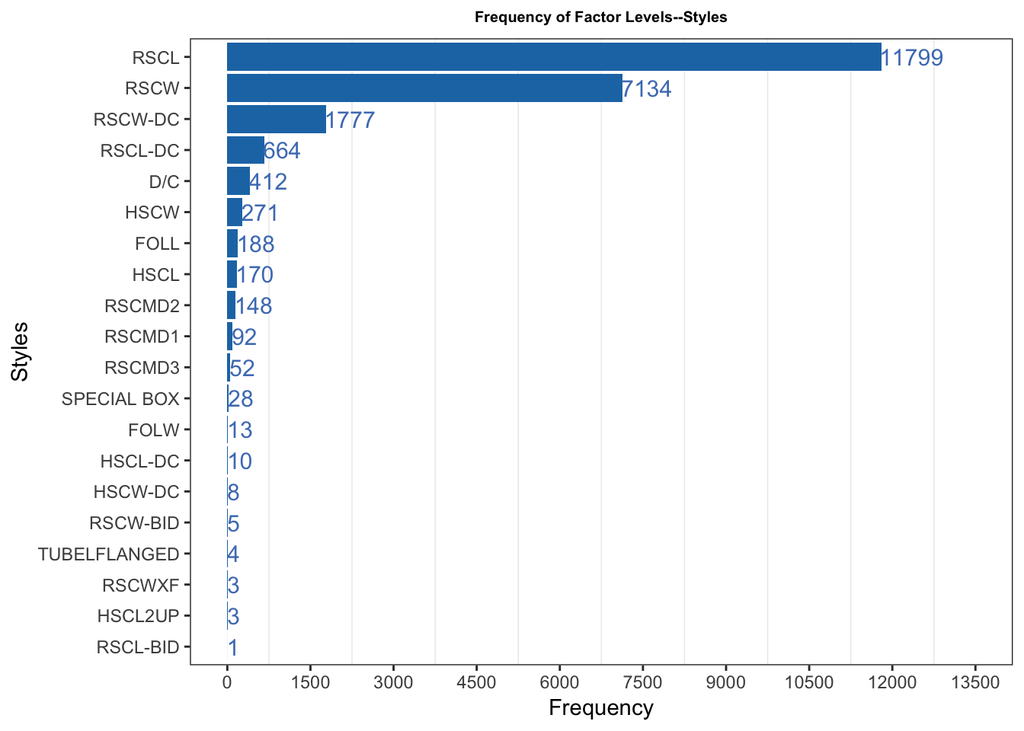

```r
library(data.table)
summ_Style <- data.frame(unclass(summary(boxFinal$Style)),check.names = FALSE, stringsAsFactors = FALSE)
summ_Style <- as.data.frame(setDT(summ_Style, keep.rownames = TRUE)[])
colnames(summ_Style) <- c("Styles","Frequency")

library(ggplot2)
Frq_Style <- ggplot()+
geom_bar(aes(x=reorder(Styles,Frequency),y=Frequency),data=summ_Style,stat="identity",fill="#1F77B4")+
geom_text(aes(x=reorder(Styles,Frequency),y=Frequency,label=Frequency),hjust=0.03,color="#4D7EBF",data=summ_Style,size=4)+
theme_bw()+coord_flip(ylim=c(0,13500))+scale_y_continuous(breaks=seq(0,13500,by=1500))+
ylab("Frequency")+xlab("Styles")+
ggtitle("Frequency of Factor Levels--Styles")+
theme(plot.title = element_text(size=7.5,face="bold",hjust = 0.5),panel.grid.major = element_blank())
Frq_Style
```

```r
boxFinal$Style <- recode_factor(boxFinal$Style, "FOLL"="OTH", "FOLW"="OTH","FOL"="OTH",
                                "HSCL"="OTH","HSCW"="OTH","RSCM"="RSC","RSCW"="RSC","HSC"="OTH",
                                "HSCL-DC"="OTH","HSCL2UP"="OTH","HSCW-DC"="OTH",
                                "RSCL-BID"="RSCL", "RSCL-DC"="RSCL", "RSCMD1"="RSC",
                                  "RSCMD2"="RSC","RSCMD3"="RSC","RSCW-BID"="RSC","RSCW-DC"="RSC",
                                "RSCWXF"="RSC","TUBELFLANGED"="OTH", "SPECIAL BOX"="OTH","D/C"="OTH")
```

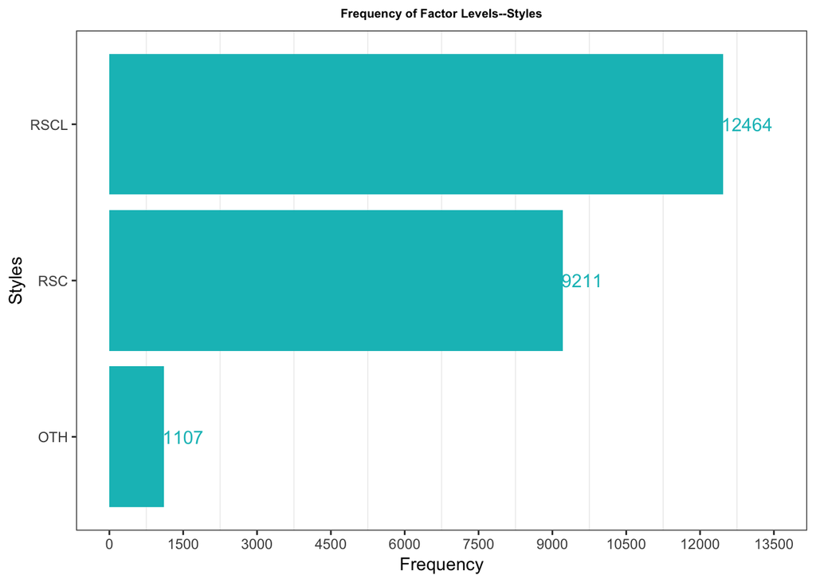

#### 1.4.2 CuttingDie

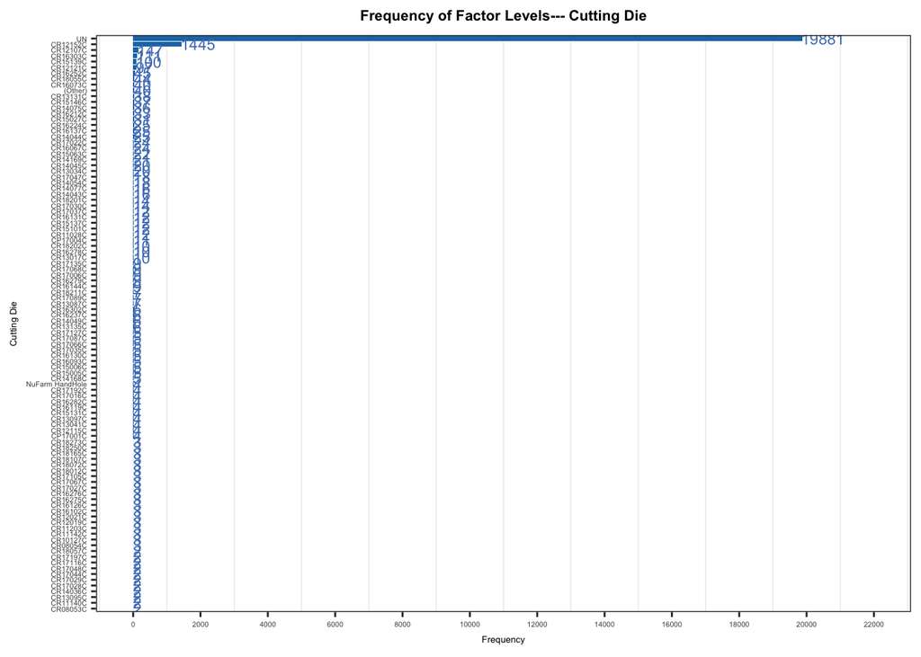

Apparently, there are a ton of factor levels. Even worse, some factor levels only have 1 or 2 occurences. If we don’t collaspe them, the degrees of freedom will be significantly increased when we build our model due to the number of dummy variables. Our model will be overfitt. Theefore, we decided to combine these factor levels by grouping everything except for UN (“unknown”) and CR12152C into a big factor level.

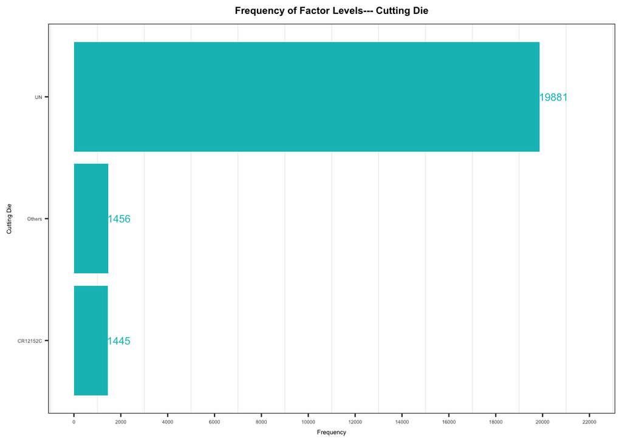

```r
boxFinal$`Cutting Die #` <- as.character(boxFinal$`Cutting Die #`)
boxFinal$`Cutting Die #`[which(boxFinal$`Cutting Die #` != "CR12152C" & boxFinal$`Cutting Die #` != "UN")] <- "Others"
boxFinal$`Cutting Die #` <- as.factor(boxFinal$`Cutting Die #`)
```

#### 1.4.3 Grade

Similar to CuttingDie, Grade also has over 100 different factor levels.We decided to combine these factor levels by the first 3-4 letters of the gradeof boxes used during production (In Grade, the first 3-4 letters represent the strength of the board. We don’t really care if the board is SFI certified or not).

```r
boxtest <-boxFinal
boxtest$Grade <- as.character(boxtest$Grade )
grade <- unique(as.factor(str_replace_all(substring(boxtest$Grade,1,4),"[^[:alnum:]]", "")))
for(i in 1:length(grade)) {
sch <- as.character(grade[i])
index <- startsWith(boxtest$Grade,sch)
boxtest$Grade[index] <- sch
}
boxtest$Grade <- as.factor(boxtest$Grade )
```

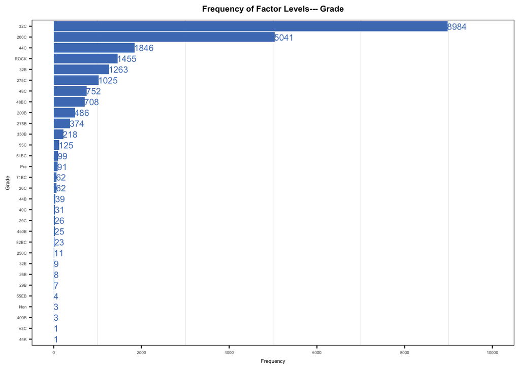

There are still too many factor levels, even after we collasped them according to the first 4 letters of the Grade. We will collaspe them further based on the number of occurences.

```r
boxtest$Grade <- recode_factor(boxtest$Grade, "ROCK"="48C", "200B"="200", "200C"="200",
                               "26B"="26", "26C"="26","275B"="275", "275C"="275","29B"="29",
                               "29C"="29", "44B"="44", "44C"="44", "44K"="44","55C"="55",
                               "55EB"="55","32B"="32","32C"="32","32E"="32")
boxtest$Grade <- recode_factor(boxtest$Grade, "26"="OTH","29"="OTH","55"="OTH","250C"="OTH",
                               "350B"="OTH", "400B"="OTH", "40C"="OTH", "450B"="OTH","48BC"="OTH",
                               "51BC"="OTH","71BC"="OTH", "82BC"="OTH","Non"="OTH","Pre"="OTH",
                               "V3C"="OTH","275"="OTH","44"="40","48C"="40")
boxFinal <- boxtest
```

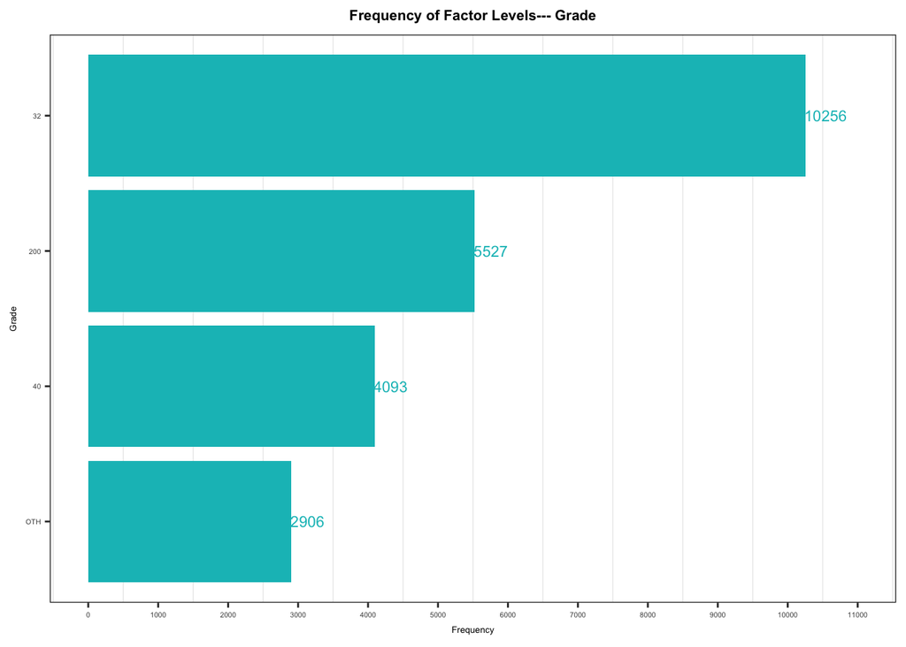

#### 1.4.4 Flute and Product Code

[figure not shown]

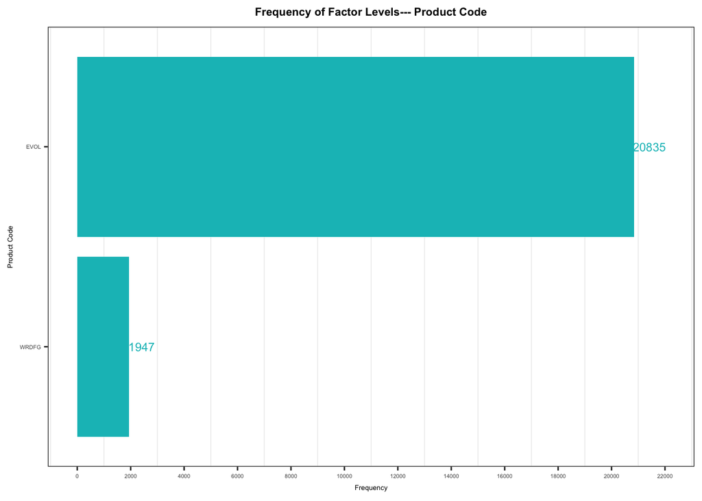

```r
boxFinal$Flute <- recode_factor(boxFinal$Flute, "BC"="B", "E"="B","EB"="B")
boxFinal$`Glue Joint` <- recode_factor(boxFinal$`Glue Joint`, "Glued 1 3/8\""="Glued")
boxFinal$`Product Code` <- recode_factor(boxFinal$`Product Code`, "MARTI"="WRDFG")
```

### 1.5 Target Variable Transformation

Our target variable is extremely right skewed.

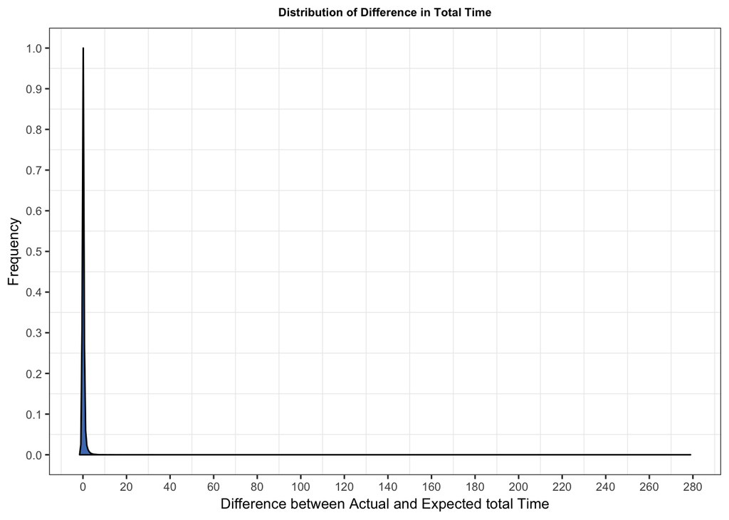

```r
ggplot() + geom_density(aes(x=Cost1,y=..scaled..),data=boxFinal,fill="#4D7EBF") +
  theme_bw()+
scale_x_continuous(breaks=seq(0,280,by=20))+ scale_y_continuous(breaks=seq(0,1,0.1))+
ylab("Frequency")+xlab("Difference between Actual and Expected total Time")+
ggtitle("Distribution of Difference in Total Time")+
theme(plot.title = element_text(size=8,face="bold",hjust = 0.5),panel.grid.major = element_blank(),
      text = element_text(size=10))
```

Before we transform our target, we would like to create two other target variables: CostRun and CostSet. CostRun is the difference between Actaul Run time and expected Run time, while CostSet is the difference between Actual Setup time and expected setup time. We will build models for these three target variable independently.

```r
boxFinal$CostSet <- boxFinal$`Actual Setup Hours`- boxFinal$`Standard Setup Hours`
boxFinal$CostRun <- boxFinal$`Actual Run Hours`- boxFinal$`Standard Run Hours`
boxFinal <- boxFinal[,-c(1:4)]
```

To eliminate the skewness of our target variable, we decided to perform logarithm transformation. A normal distribution is required if we want to build a linear regression model. It is not required if we are building a tree model. That is why we are keeping both our log-transformed target varibales and target variables that have not been transformed in our dataset.

```r
boxFinal$Cost1log <- log10(boxFinal$Cost1 + 1 - min(boxFinal$Cost1))
boxFinal$CostSetlog <- log10(boxFinal$CostSet + 1 - min(boxFinal$CostSet))
boxFinal$CostRunlog <- log10(boxFinal$CostRun + 1 - min(boxFinal$CostRun))
```

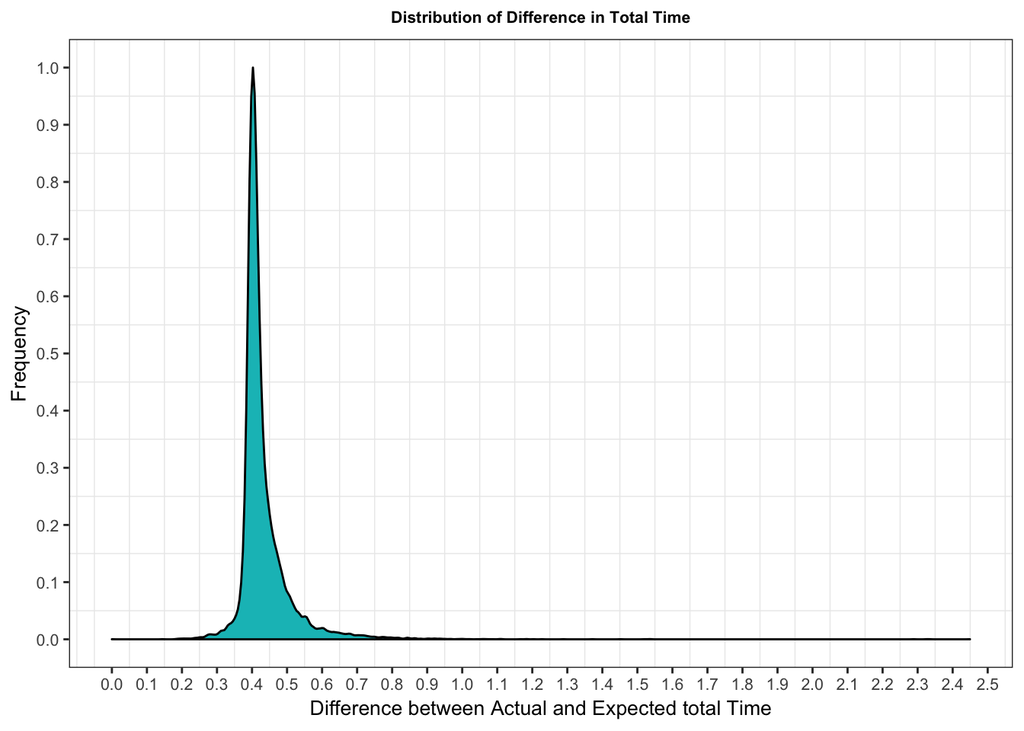

### 1.6 Dummy Variables

We then created the dummy varaibles using model.matrix.

```r
boxFinal$`HH, Attachments` <- as.character(boxFinal$`HH, Attachments`)
boxFinal$`HH, Attachments`[which(boxFinal$`HH, Attachments`=="1")] <- "Y"
boxFinal$`HH, Attachments` <- as.factor(boxFinal$`HH, Attachments`)
box.nums <- boxFinal %>% select_if(is.numeric)
box.cats <- select_if(boxFinal,negate(is.numeric))
dummies <- model.matrix( ~.,data=box.cats)
dummies <- as.data.frame(dummies)
dummies <- dummies[,-1]
dummies <- lapply(dummies,factor)
dummies <- as.data.frame(dummies)
box <- cbind(box.nums,dummies)
colnames(box) <- c("GrossQTYRan","NumPerUnit","NumPerBundle","BoxLength","BoxWidth","BoxDepth",
                        "SheetLength","SheetWidth","NumInk","PercInk","Cost1","prodmonth","CostSet","CostRun","Cost1log",
                        "CostSetlog","CostRunlog","Machine4","ProductCodeEVOL","StyleRSC", "StyleRSCL",
                        "CuttingDieOthers","CuttingDieUN","Grade40","Grade200","Grade32","FluteC","GlueJointGlue","WRAY",
                        "33Medium","26Medium","RockTennMRA","NUGHZ","NUG","40Medium","WRADW","33MediumDW","26MediumDW",
                        "Michelman40E","250BoxUnit","500BoxUnit","100Coverage","15PerBundle","BoxWidth55","DCAttachment",
                        "EaInkChange","EaPlateChange","ExtGlueTab","FullDieCut","FullPartDC","HHAttachment","Ink50")
data.summary(box)
```

```
##                       mean            sd       min           max
## GrossQTYRan  4878.70244052 7304.25266789 28.000000 126199.000000
## NumPerUnit    525.73746818  317.82487131  0.000000   4200.000000
## NumPerBundle    6.17320692    9.10405568  0.000000     50.000000
## BoxLength      14.97133428    4.33674075  6.000000     44.250000
## BoxWidth       10.12790251    3.05501820  3.000000     21.875000
## BoxDepth        8.91066961    3.30915569  0.000000     25.625000
## SheetLength    52.16296857   13.22391644 18.625000     90.500000
## SheetWidth     19.53276984    4.74700397  8.625000     85.000000
## NumInk          0.90022825    0.72518028  0.000000      4.000000
## PercInk         0.13152752    0.11867197  0.000000      1.020000
## Cost1           0.27153525    3.08278380 -1.516847    278.915220
## prodmonth       7.08098499    3.35235653  1.000000     12.000000
## CostSet         0.02532534    0.26418995 -1.167100     14.986100
## CostRun         0.24620990    3.05080210 -1.626647    277.190320
## Cost1log        0.43177889    0.07687118  0.000000      2.449374
## CostSetlog      0.33883437    0.03991133  0.000000      1.234345
## CostRunlog      0.44743071    0.06477647  0.000000      2.446874
##                     median length missing
## GrossQTYRan  2161.00000000  22782       0
## NumPerUnit    500.00000000  22782       0
## NumPerBundle    0.00000000  22782       0
## BoxLength      14.25000000  22782       0
## BoxWidth       10.00000000  22782       0
## BoxDepth        8.75000000  22782       0
## SheetLength    51.00000000  22782       0
## SheetWidth     19.00000000  22782       0
## NumInk          1.00000000  22782       0
## PercInk         0.15000000  22782       0
## Cost1           0.06404905  22782       0
## prodmonth       8.00000000  22782       0
## CostSet        -0.01240000  22782       0
## CostRun         0.05504380  22782       0
## Cost1log        0.41177048  22782       0
## CostSetlog      0.33338681  22782       0
## CostRunlog      0.42840867  22782       0
##                  levels mode missing
## Machine4              2    1       0
## ProductCodeEVOL       2    1       0
## StyleRSC              2    0       0
```

[output cut: 17 more lines]

```
## 26MediumDW            2    0       0
## Michelman40E          2    0       0
## 250BoxUnit            2    0       0
## 500BoxUnit            2    0       0
## 100Coverage           2    0       0
## 15PerBundle           2    0       0
## BoxWidth55            2    0       0
## DCAttachment          2    0       0
## EaInkChange           2    0       0
## EaPlateChange         2    0       0
## ExtGlueTab            2    0       0
## FullDieCut            2    0       0
## FullPartDC            2    0       0
## HHAttachment          2    0       0
## Ink50                 2    0       0
```

### 1.7 Multicollinearity

Eventually, we chacked to see if there are any significant multicollinearity between the variables in our dataset.

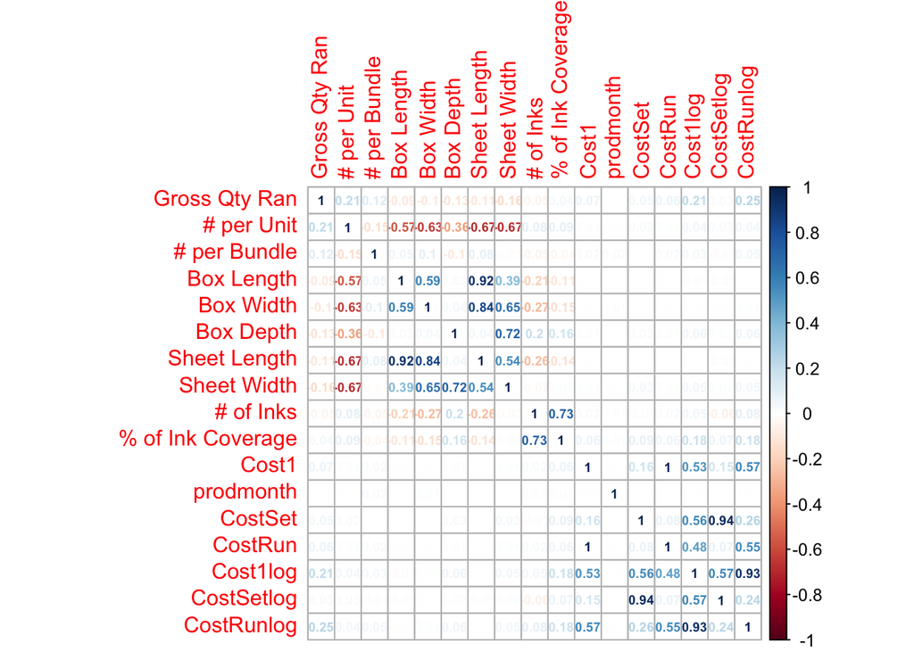

```r
library(corrplot)
M<-cor(box.nums)
corrplot(M,method = "number", number.cex = 0.6)
```

### 1.8 Training/Validation Partitioning

We then devided our dataset into training and validation partitions. Some modeling methods require a smaller training data, while others require a laeger training data size. We would make 75% of the total observations our training data.

```r
set.seed(13)
index<-sample(1:nrow(box), size=round(0.75*nrow(box)))
training <- box[index,]
validation <- box[-index,]
```

## 2. Modeling

Before we even start to model, lets figure out what could be the primary cost driver:

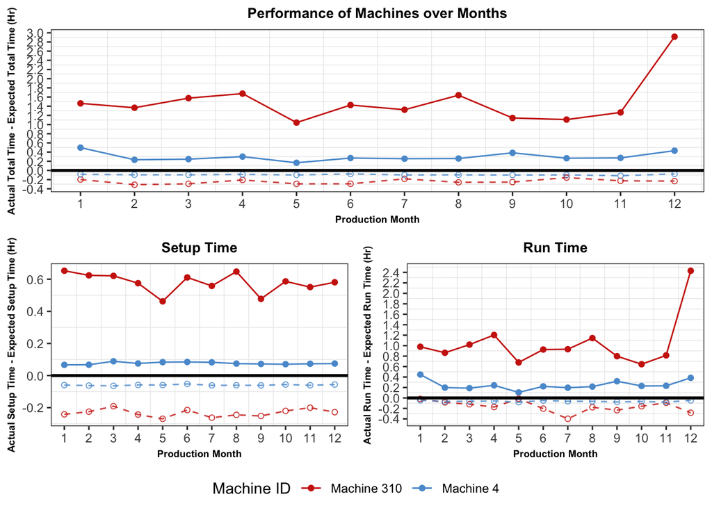

From the graph above, we can tell Machine type plays a significant role in determining the difference between actual and expected time. Machine 310 seems to be the slower machine and the major cost driver.